# solar_adoption_analysis_australia-ARENA

## Solar Energy Adoption Analysis in Australia for ARENA

> - **Prepared by:** Lai Kuen Tsang, Applied Data Analysis Skill Set Course at TAFE
> - **Date:** 20th April, 2026
> - **Confidentiality:** Internal (Assignment)

## Executive Summary

This report analyses solar installation adoption trends across Australian states using installation, population, and postcode mapping datasets. The objective was to identify growth patterns, regional differences, and per-capita adoption rates to better understand Australia's solar adoption landscape.

When adjusting for population, per-capita adoption revealed different insights, with some smaller states demonstrating relatively higher adoption rates compared to larger states. This suggests that regional policies, incentives, and environmental factors may influence adoption beyond population size alone.

Year-on-year growth analysis also showed periods of accelerated growth, likely influenced by government incentives, declining solar installation costs, and increased awareness of renewable energy benefits.

These insights provide valuable information for policy makers, energy providers, and businesses to better understand solar adoption trends and identify future opportunities for renewable energy expansion.

## Introduction

- **Objectives:**

The objective of this analysis is to examine solar installation trends across Australian states, identify growth patterns, and evaluate adoption rates over time. The analysis aims to assess market performance using key metrics such as total installations, capacity growth, and population-normalised adoption rates.

- **Approach:**

The analysis was conducted using historical solar installation data combined with population data. The dataset was cleaned, merged, and aggregated by state, year, and quarter. Additional features including year, quarter, and per-capita installation rates were derived to support trend analysis. Key performance indicators including total installations, quarter-on-quarter growth, and year-on-year growth were calculated to evaluate performance.

## Methodology

### Data sources:

There are data sources we gather from:

sources = { 'CER_CAP': '../data/sgu-solar-capacity-2011-to-present-and-totals.csv', 'CER_INS': '../data/sgu-solar-installations-2011-to-present-and-totals.csv',

```
#Two extra data sources:
'ABS': 'https://www.abs.gov.au/statistics/people/population/national-state-and-territory-population/latest-release#states-and-territories' : Population_by_State 2011_2025.csv

'AU_map postcode to states': 'https://github.com/matthewproctor/australianpostcodes/blob/master/australian_postcodes.csv
```

### Data Extraction

```python
import pandas as pd
```

Load ARENA and ABS datasets

1. Installation data from ARNEA: df_ins = pd.read_csv(../sgu-solar-installations-2011-to-present-and-totals.csv)
2. Capacity(kw) data from ARNEA: df_cap = pd.read_csv(../sgu-solar-capacity-2011-to-present-and-totals.csv)
3. Mapping data of postcode and State: df_pc = pd.read_csv(../australian_postcodes.csv)
4. Mapping data of state and population: df_pop = pd.read_csv(../Population_by_State 2011_2025.csv)

### Analystical Tools

The following analytical tools and techniques were used in this analysis reports:

#### Tools:

- Python
- Pandas for data manipulation and aggregation
- Numpy for Numerical computation
- Matplotlib for data visualization

#### Analytical Techniques:

- Data cleaning and preprocessing
- Data merging and tranformation
- Dervied data vaiables for periods and growth analysis
- Time-series analysis
- Per capita analysis
- Trend and growth rate analysis per quarterly and yearly

### Data Collation and Preparation

```python
df_cap = pd.read_csv(r'/Users/polly/Downloads/Applied Data Analysis Skill Set/Assessment_2 Due in Apr 5_10/sgu-solar-capacity-2011-to-present-and-totals.csv')
df_ins = pd.read_csv(r'/Users/polly/Downloads/Applied Data Analysis Skill Set/Assessment_2 Due in Apr 5_10/sgu-solar-installations-2011-to-present-and-totals.csv')
df_pop = pd.read_csv(r'/Users/polly/Downloads/Applied Data Analysis Skill Set/Assessment_2 Due in Apr 5_10/Population_by_State 2011_2025.csv')
df_pc = pd.read_csv(r'/Users/polly/Downloads/Applied Data Analysis Skill Set/Assessment_2 Due in Apr 5_10/australian_postcodes.csv')
```

- **Read installation file as df_ins**

```python
df_ins = pd.read_csv(r'/Users/polly/Downloads/Applied Data Analysis Skill Set/Assessment_2 Due in Apr 5_10/sgu-solar-installations-2011-to-present-and-totals.csv')
df_ins
```

|  | Small Unit Installation Postcode | Historic Total Installation Quantity (2001 - 2010) | Jan 2011 - Installation Quantity | Feb 2011 - Installation Quantity | Mar 2011 - Installation Quantity | Apr 2011 - Installation Quantity | May 2011 - Installation Quantity | Jun 2011 - Installation Quantity | Jul 2011 - Installation Quantity | Aug 2011 - Installation Quantity | ... | May 2025 - Installation Quantity | Jun 2025 - Installation Quantity | Jul 2025 - Installation Quantity | Aug 2025 - Installation Quantity | Sep 2025 - Installation Quantity | Oct 2025 - Installation Quantity | Nov 2025 - Installation Quantity | Dec 2025 - Installation Quantity | Jan 2026 - Installation Quantity | Total Installation Quantity |
| --- | --- | --- | --- | --- | --- | --- | --- | --- | --- | --- | --- | --- | --- | --- | --- | --- | --- | --- | --- | --- | --- |
| 0 | 0 | 4 | 0 | 0 | 0 | 0 | 0 | 0 | 0 | 0 | ... | 0 | 0 | 0 | 0 | 0 | 0 | 0 | 0 | 0 | 4 |
| 1 | 200 | 1 | 0 | 0 | 0 | 0 | 0 | 0 | 0 | 0 | ... | 0 | 0 | 0 | 0 | 0 | 0 | 0 | 0 | 0 | 1 |
| 2 | 800 | 7 | 0 | 0 | 0 | 0 | 1 | 0 | 1 | 0 | ... | 0 | 2 | 1 | 0 | 0 | 0 | 1 | 0 | 0 | 150 |
| 3 | 801 | 2 | 0 | 0 | 0 | 0 | 1 | 0 | 0 | 0 | ... | 0 | 0 | 0 | 0 | 0 | 0 | 0 | 0 | 0 | 12 |
| 4 | 803 | 0 | 0 | 0 | 0 | 0 | 0 | 0 | 0 | 0 | ... | 0 | 0 | 0 | 0 | 0 | 0 | 0 | 0 | 0 | 2 |
| ... | ... | ... | ... | ... | ... | ... | ... | ... | ... | ... | ... | ... | ... | ... | ... | ... | ... | ... | ... | ... | ... |
| 2806 | 7469 | 2 | 0 | 0 | 1 | 0 | 1 | 0 | 0 | 0 | ... | 0 | 0 | 1 | 0 | 1 | 0 | 1 | 0 | 0 | 80 |
| 2807 | 7470 | 1 | 0 | 0 | 0 | 0 | 0 | 0 | 0 | 0 | ... | 1 | 0 | 0 | 0 | 0 | 0 | 0 | 1 | 0 | 75 |
| 2808 | 7802 | 1 | 0 | 0 | 0 | 0 | 0 | 0 | 0 | 0 | ... | 0 | 0 | 0 | 0 | 0 | 0 | 0 | 0 | 0 | 1 |
| 2809 | 8576 | 0 | 0 | 0 | 1 | 0 | 0 | 0 | 0 | 0 | ... | 0 | 0 | 0 | 0 | 0 | 0 | 0 | 0 | 0 | 2 |
| 2810 | 9729 | 1 | 0 | 0 | 0 | 0 | 0 | 0 | 0 | 0 | ... | 0 | 0 | 0 | 0 | 0 | 0 | 0 | 0 | 0 | 1 |

2811 rows × 184 columns

```python
#remove unwanted columns
df_ins = df_ins.drop(columns=['Historic Total Installation Quantity (2001 - 2010)','Total Installation Quantity'])
```

```python
#remove space
df_ins.columns = df_ins.columns.str.strip()
```

```python
#rename the primary key
df_ins.rename(columns={'Small Unit Installation Postcode':'postcode'}, inplace = True)
```

```python
#set postcode as string and standardlize it
df_ins['postcode']=df_ins['postcode'].astype('string')
df_ins['postcode']=df_ins['postcode'].str.zfill(4)
```

```python
#unpivot the table
df_ins = pd.melt(df_ins,id_vars='postcode',var_name ='date',value_name='install_qty')
df_ins
```

|  | postcode | date | install_qty |
| --- | --- | --- | --- |
| 0 | 0000 | Jan 2011 - Installation Quantity | 0 |
| 1 | 0200 | Jan 2011 - Installation Quantity | 0 |
| 2 | 0800 | Jan 2011 - Installation Quantity | 0 |
| 3 | 0801 | Jan 2011 - Installation Quantity | 0 |
| 4 | 0803 | Jan 2011 - Installation Quantity | 0 |
| ... | ... | ... | ... |
| 508786 | 7469 | Jan 2026 - Installation Quantity | 0 |
| 508787 | 7470 | Jan 2026 - Installation Quantity | 0 |
| 508788 | 7802 | Jan 2026 - Installation Quantity | 0 |
| 508789 | 8576 | Jan 2026 - Installation Quantity | 0 |
| 508790 | 9729 | Jan 2026 - Installation Quantity | 0 |

508791 rows × 3 columns

```python
# Remove " - Installation Quantity"
df_ins['date'] = df_ins['date'].str.strip().str.replace('- Installation Quantity','',regex = False)
```

```python
#remove space and empty data
df_ins['date'] = df_ins['date'].astype(str).str.strip()
```

```python
#remove empty date data
df_ins = df_ins[df_ins['date'] != '']
```

```python
#set Datetime format
df_ins['date'] = pd.to_datetime(df_ins['date'],format = '%b %Y')
```

```python
#get year value from date
df_ins['year']= df_ins['date'].dt.year
```

```python
#get quarter value from date
df_ins['quarter']= df_ins['date'].dt.to_period('Q')
```

```python
#remove postcode 0000
df_ins = df_ins[df_ins['postcode'] != '0000'].reset_index(drop=True)
```

```python
#check the duplicated records
df_ins.duplicated(subset=['postcode','date','year','quarter']).sum()
```

```
np.int64(0)
```

- **Read Capacity file as df_cap**

```python
df_cap = pd.read_csv(r'/Users/polly/Downloads/Applied Data Analysis Skill Set/Assessment_2 Due in Apr 5_10/sgu-solar-capacity-2011-to-present-and-totals.csv')
df_cap
```

|  | Small Unit Postcode | Historic Total Rated Power Output In kW (2001 - 2010) | Jan 2011 - Rated Power Output In kW | Feb 2011 - Rated Power Output In kW | Mar 2011 - Rated Power Output In kW | Apr 2011 - Rated Power Output In kW | May 2011 - Rated Power Output In kW | Jun 2011 - Rated Power Output In kW | Jul 2011 - Rated Power Output In kW | Aug 2011 - Rated Power Output In kW | ... | May 2025 - Rated Power Output In kW | Jun 2025 - Rated Power Output In kW | Jul 2025 - Rated Power Output In kW | Aug 2025 - Rated Power Output In kW | Sep 2025 - Rated Power Output In kW | Oct 2025 - Rated Power Output In kW | Nov 2025 - Rated Power Output In kW | Dec 2025 - Rated Power Output In kW | Jan 2026 - Rated Power Output In kW | Total Rated Power Output In kW |
| --- | --- | --- | --- | --- | --- | --- | --- | --- | --- | --- | --- | --- | --- | --- | --- | --- | --- | --- | --- | --- | --- |
| 0 | 0 | 4.460 | 0.0 | 0.0 | 0.00 | 0.0 | 0.000 | 0.000 | 0.00 | 0.0 | ... | 0.000 | 0.000 | 0.000 | 0.000 | 0.000 | 0.000 | 0.000 | 0.000 | 0.0 | 4.460 |
| 1 | 200 | 0.080 | 0.0 | 0.0 | 0.00 | 0.0 | 0.000 | 0.000 | 0.00 | 0.0 | ... | 0.000 | 0.000 | 0.000 | 0.000 | 0.000 | 0.000 | 0.000 | 0.000 | 0.0 | 0.080 |
| 2 | 800 | 34.740 | 0.0 | 0.0 | 0.00 | 0.0 | 2.220 | 0.000 | 3.04 | 0.0 | ... | 0.000 | 164.230 | 99.880 | 0.000 | 0.000 | 0.000 | 21.120 | 0.000 | 0.0 | 5,148.615 |
| 3 | 801 | 3.440 | 0.0 | 0.0 | 0.00 | 0.0 | 2.020 | 0.000 | 0.00 | 0.0 | ... | 0.000 | 0.000 | 0.000 | 0.000 | 0.000 | 0.000 | 0.000 | 0.000 | 0.0 | 386.598 |
| 4 | 803 | 0.000 | 0.0 | 0.0 | 0.00 | 0.0 | 0.000 | 0.000 | 0.00 | 0.0 | ... | 0.000 | 0.000 | 0.000 | 0.000 | 0.000 | 0.000 | 0.000 | 0.000 | 0.0 | 11.685 |
| ... | ... | ... | ... | ... | ... | ... | ... | ... | ... | ... | ... | ... | ... | ... | ... | ... | ... | ... | ... | ... | ... |
| 2806 | 7469 | 2.100 | 0.0 | 0.0 | 1.56 | 0.0 | 1.645 | 0.000 | 0.00 | 0.0 | ... | 0.000 | 0.000 | 1.760 | 0.000 | 6.600 | 0.000 | 6.650 | 0.000 | 0.0 | 445.865 |
| 2807 | 7470 | 1.020 | 0.0 | 0.0 | 0.00 | 0.0 | 0.000 | 0.000 | 0.00 | 0.0 | ... | 6.580 | 0.000 | 0.000 | 0.000 | 0.000 | 0.000 | 0.000 | 15.400 | 0.0 | 423.962 |
| 2808 | 7802 | 2.450 | 0.0 | 0.0 | 0.00 | 0.0 | 0.000 | 0.000 | 0.00 | 0.0 | ... | 0.000 | 0.000 | 0.000 | 0.000 | 0.000 | 0.000 | 0.000 | 0.000 | 0.0 | 2.450 |
| 2809 | 8576 | 0.000 | 0.0 | 0.0 | 1.90 | 0.0 | 0.000 | 0.000 | 0.00 | 0.0 | ... | 0.000 | 0.000 | 0.000 | 0.000 | 0.000 | 0.000 | 0.000 | 0.000 | 0.0 | 6.840 |
| 2810 | 9729 | 0.875 | 0.0 | 0.0 | 0.00 | 0.0 | 0.000 | 0.000 | 0.00 | 0.0 | ... | 0.000 | 0.000 | 0.000 | 0.000 | 0.000 | 0.000 | 0.000 | 0.000 | 0.0 | 0.875 |

2811 rows × 184 columns

```python
#remove unwanted columns
df_cap = df_cap.drop(columns=['Historic Total Rated Power Output In kW (2001 - 2010)','Total Rated Power Output In kW'])
```

```python
#remove space
df_cap.columns = df_cap.columns.str.strip()
```

```python
#rename the primary key
df_cap.rename(columns={'Small Unit Postcode':'postcode'}, inplace = True)
```

```python
#set postcode as string and standardlize it
df_cap['postcode']=df_cap['postcode'].astype('string')
df_cap['postcode']=df_cap['postcode'].str.zfill(4)
```

```python
#unpivot the table
df_cap = pd.melt(df_cap,id_vars='postcode',var_name ='date',value_name='capacity_kw')
```

```python
# Remove " - Rated Power Output In kW"
df_cap['date'] = df_cap['date'].str.strip().str.replace(' - Rated Power Output In kW','',regex = False)
```

```python
#remove space and empty data
df_cap['date'] = df_cap['date'].astype(str).str.strip()
```

```python
#remove empty date data
df_cap = df_cap[df_cap['date'] != '']
```

```python
#set Datetime format
df_cap['date'] = pd.to_datetime(df_cap['date'],format = '%b %Y')
```

```python
df_cap.info()
```

[output not shown]

```python
#convert capacity_kw datatype to float
df_cap['capacity_kw'] = (df_cap['capacity_kw'].astype(str).str.replace(',', '').str.strip())
df_cap['capacity_kw'] = pd.to_numeric(df_cap['capacity_kw'], errors='coerce')
```

```python
df_cap['capacity_kw'] = df_cap['capacity_kw'].round(2)
```

```python
#get year value from date
df_cap['year']= df_cap['date'].dt.year
```

```python
#get quarter value from date
df_cap['quarter']= df_cap['date'].dt.to_period('Q')
df_cap
```

|  | postcode | date | capacity_kw | year | quarter |
| --- | --- | --- | --- | --- | --- |
| 0 | 0000 | 2011-01-01 | 0.0 | 2011 | 2011Q1 |
| 1 | 0200 | 2011-01-01 | 0.0 | 2011 | 2011Q1 |
| 2 | 0800 | 2011-01-01 | 0.0 | 2011 | 2011Q1 |
| 3 | 0801 | 2011-01-01 | 0.0 | 2011 | 2011Q1 |
| 4 | 0803 | 2011-01-01 | 0.0 | 2011 | 2011Q1 |
| ... | ... | ... | ... | ... | ... |
| 508786 | 7469 | 2026-01-01 | 0.0 | 2026 | 2026Q1 |
| 508787 | 7470 | 2026-01-01 | 0.0 | 2026 | 2026Q1 |
| 508788 | 7802 | 2026-01-01 | 0.0 | 2026 | 2026Q1 |
| 508789 | 8576 | 2026-01-01 | 0.0 | 2026 | 2026Q1 |
| 508790 | 9729 | 2026-01-01 | 0.0 | 2026 | 2026Q1 |

508791 rows × 5 columns

```python
#remove postcode 0000
df_cap = df_cap[df_cap['postcode'] != '0000'].reset_index(drop=True)
```

```python
#check the duplicated records
df_cap.duplicated(subset=['postcode','date','year','quarter']).sum()
```

```
np.int64(0)
```

- **Read population file as df_pop**

```python
df_pop = pd.read_csv(r'/Users/polly/Downloads/Applied Data Analysis Skill Set/Assessment_2 Due in Apr 5_10/Population_by_State 2011_2025.csv')
df_pop
```

|  | Unnamed: 0 | Estimated Resident Population ; Male ; New South Wales ; | Estimated Resident Population ; Male ; Victoria ; | Estimated Resident Population ; Male ; Queensland ; | Estimated Resident Population ; Male ; South Australia ; | Estimated Resident Population ; Male ; Western Australia ; | Estimated Resident Population ; Male ; Tasmania ; | Estimated Resident Population ; Male ; Northern Territory ; | Estimated Resident Population ; Male ; Australian Capital Territory ; | Estimated Resident Population ; Male ; Australia ; | ... | Estimated Resident Population ; Female ; Australia ; | Estimated Resident Population ; Persons ; New South Wales ; | Estimated Resident Population ; Persons ; Victoria ; | Estimated Resident Population ; Persons ; Queensland ; | Estimated Resident Population ; Persons ; South Australia ; | Estimated Resident Population ; Persons ; Western Australia ; | Estimated Resident Population ; Persons ; Tasmania ; | Estimated Resident Population ; Persons ; Northern Territory ; | Estimated Resident Population ; Persons ; Australian Capital Territory ; | Estimated Resident Population ; Persons ; Australia ; |
| --- | --- | --- | --- | --- | --- | --- | --- | --- | --- | --- | --- | --- | --- | --- | --- | --- | --- | --- | --- | --- | --- |
| 0 | Unit | Persons | Persons | Persons | Persons | Persons | Persons | Persons | Persons | Persons | ... | Persons | Persons | Persons | Persons | Persons | Persons | Persons | Persons | Persons | Persons |
| 1 | Series Type | Original | Original | Original | Original | Original | Original | Original | Original | Original | ... | Original | Original | Original | Original | Original | Original | Original | Original | Original | Original |
| 2 | Data Type | STOCK_CLOSE | STOCK_CLOSE | STOCK_CLOSE | STOCK_CLOSE | STOCK_CLOSE | STOCK_CLOSE | STOCK_CLOSE | STOCK_CLOSE | STOCK_CLOSE | ... | STOCK_CLOSE | STOCK_CLOSE | STOCK_CLOSE | STOCK_CLOSE | STOCK_CLOSE | STOCK_CLOSE | STOCK_CLOSE | STOCK_CLOSE | STOCK_CLOSE | STOCK_CLOSE |
| 3 | Frequency | Quarter | Quarter | Quarter | Quarter | Quarter | Quarter | Quarter | Quarter | Quarter | ... | Quarter | Quarter | Quarter | Quarter | Quarter | Quarter | Quarter | Quarter | Quarter | Quarter |
| 4 | Collection Month | 3 | 3 | 3 | 3 | 3 | 3 | 3 | 3 | 3 | ... | 3 | 3 | 3 | 3 | 3 | 3 | 3 | 3 | 3 | 3 |
| ... | ... | ... | ... | ... | ... | ... | ... | ... | ... | ... | ... | ... | ... | ... | ... | ... | ... | ... | ... | ... | ... |
| 182 | Sep-2024 | 4239370 | 3446941 | 2771134 | 933594 | 1506853 | 285186 | 134555 | 235849 | 13556115 | ... | 13745034 | 8518984 | 6982339 | 5595295 | 1887076 | 2995905 | 575068 | 261727 | 479769 | 27301149 |
| 183 | Dec-2024 | 4247233 | 3457529 | 2782864 | 935638 | 1514108 | 285393 | 135074 | 236195 | 13596670 | ... | 13791463 | 8536892 | 7005996 | 5619534 | 1891365 | 3010266 | 575475 | 262553 | 481054 | 27388133 |
| 184 | Mar-2025 | 4265592 | 3478839 | 2797243 | 939456 | 1525048 | 285616 | 135826 | 237023 | 13667281 | ... | 13864162 | 8574064 | 7050570 | 5648264 | 1898981 | 3031308 | 576067 | 263862 | 483324 | 27531443 |
| 185 | Jun-2025 | 4274825 | 3489957 | 2808163 | 941272 | 1531884 | 285671 | 136264 | 237604 | 13708285 | ... | 13905369 | 8592524 | 7073859 | 5669764 | 1902665 | 3044382 | 576261 | 264556 | 484630 | 27613654 |
| 186 | Sep-2025 | 4291069 | 3505107 | 2819820 | 944311 | 1541187 | 285790 | 136855 | 238287 | 13765078 | ... | 13959666 | 8624534 | 7104349 | 5692642 | 1908182 | 3061672 | 576659 | 265457 | 486231 | 27724744 |

187 rows × 28 columns

```python
#remove unwanted rows
df_pop = df_pop.iloc[9:]
```

```python
#rename date columns and reset index
df_pop = df_pop.rename(columns={'Unnamed: 0':'date'}).reset_index(drop=True)
```

```python
#clean columns
df_pop.columns = (df_pop.columns.str.strip().str.replace(';','_').str.rstrip('_').str.lower())
```

```python
#unpivot the table
df_pop = pd.melt(df_pop,id_vars = ['date'],var_name = 'state', value_name = 'population')
```

```python
#set date as datetime
df_pop['date'] = pd.to_datetime(df_pop['date'],format = '%b-%Y')
```

```python
#substract state from one column
df_pop[['est','gender','state']]=df_pop['state'].str.rsplit('_', n=2, expand = True)
df_pop
```

|  | date | state | population | est | gender |
| --- | --- | --- | --- | --- | --- |
| 0 | 1981-06-01 | new south wales | 2608351 | estimated resident population | male |
| 1 | 1981-09-01 | new south wales | 2616060 | estimated resident population | male |
| 2 | 1981-12-01 | new south wales | 2624579 | estimated resident population | male |
| 3 | 1982-03-01 | new south wales | 2634534 | estimated resident population | male |
| 4 | 1982-06-01 | new south wales | 2643527 | estimated resident population | male |
| ... | ... | ... | ... | ... | ... |
| 4801 | 2024-09-01 | australia | 27301149 | estimated resident population | persons |
| 4802 | 2024-12-01 | australia | 27388133 | estimated resident population | persons |
| 4803 | 2025-03-01 | australia | 27531443 | estimated resident population | persons |
| 4804 | 2025-06-01 | australia | 27613654 | estimated resident population | persons |
| 4805 | 2025-09-01 | australia | 27724744 | estimated resident population | persons |

4806 rows × 5 columns

```python
#clean columns
df_pop['gender'] = df_pop['gender'].str.strip()
df_pop['state'] = df_pop['state'].str.strip()
```

```python
# only keep "persons" records for the population no.
df_pop = df_pop[df_pop['gender'].str.strip()=='persons']
```

```python
# drop "australia" records
df_pop = df_pop[df_pop['state'].str.strip()!='australia']
```

```python
df_pop.reset_index(drop=True)
```

|  | date | state | population | est | gender |
| --- | --- | --- | --- | --- | --- |
| 0 | 1981-06-01 | new south wales | 5234889 | estimated resident population | persons |
| 1 | 1981-09-01 | new south wales | 5249455 | estimated resident population | persons |
| 2 | 1981-12-01 | new south wales | 5266894 | estimated resident population | persons |
| 3 | 1982-03-01 | new south wales | 5286119 | estimated resident population | persons |
| 4 | 1982-06-01 | new south wales | 5303580 | estimated resident population | persons |
| ... | ... | ... | ... | ... | ... |
| 1419 | 2024-09-01 | australian capital territory | 479769 | estimated resident population | persons |
| 1420 | 2024-12-01 | australian capital territory | 481054 | estimated resident population | persons |
| 1421 | 2025-03-01 | australian capital territory | 483324 | estimated resident population | persons |
| 1422 | 2025-06-01 | australian capital territory | 484630 | estimated resident population | persons |
| 1423 | 2025-09-01 | australian capital territory | 486231 | estimated resident population | persons |

1424 rows × 5 columns

```python
#remove unwanted columns
df_pop = df_pop.drop(columns = ['est','gender'])
df_pop
```

|  | date | state | population |
| --- | --- | --- | --- |
| 3204 | 1981-06-01 | new south wales | 5234889 |
| 3205 | 1981-09-01 | new south wales | 5249455 |
| 3206 | 1981-12-01 | new south wales | 5266894 |
| 3207 | 1982-03-01 | new south wales | 5286119 |
| 3208 | 1982-06-01 | new south wales | 5303580 |
| ... | ... | ... | ... |
| 4623 | 2024-09-01 | australian capital territory | 479769 |
| 4624 | 2024-12-01 | australian capital territory | 481054 |
| 4625 | 2025-03-01 | australian capital territory | 483324 |
| 4626 | 2025-06-01 | australian capital territory | 484630 |
| 4627 | 2025-09-01 | australian capital territory | 486231 |

1424 rows × 3 columns

```python
#set correct data type
df_pop['state'] = df_pop['state'].astype('string').str.strip()
df_pop['population'] = df_pop['population'].astype(int)
```

```python
# adding state_abbr

state_abbr = {
    'new south wales' : 'NSW',
    'victoria': 'VIC' ,
    'queensland': 'QLD',
    'south australia' :'SA',
    'western australia': 'WA',
    'northern territory':'NT',
    'australian capital territory' : 'ACT',
    'tasmania':'TAS',
    'australia':'AU'
}

df_pop['state_abbr'] = df_pop['state'].map(state_abbr)
```

```python
df_pop.reset_index(drop = True)
```

|  | date | state | population | state_abbr |
| --- | --- | --- | --- | --- |
| 0 | 1981-06-01 | new south wales | 5234889 | NSW |
| 1 | 1981-09-01 | new south wales | 5249455 | NSW |
| 2 | 1981-12-01 | new south wales | 5266894 | NSW |
| 3 | 1982-03-01 | new south wales | 5286119 | NSW |
| 4 | 1982-06-01 | new south wales | 5303580 | NSW |
| ... | ... | ... | ... | ... |
| 1419 | 2024-09-01 | australian capital territory | 479769 | ACT |
| 1420 | 2024-12-01 | australian capital territory | 481054 | ACT |
| 1421 | 2025-03-01 | australian capital territory | 483324 | ACT |
| 1422 | 2025-06-01 | australian capital territory | 484630 | ACT |
| 1423 | 2025-09-01 | australian capital territory | 486231 | ACT |

1424 rows × 4 columns

```python
#Use state_abbr as state
df_pop = df_pop.drop(columns = ['state'])
df_pop = df_pop.rename(columns ={'state_abbr':'state'})
df_pop = df_pop.reset_index(drop = True)
```

```python
#add quarter & year
df_pop['quarter'] = df_pop['date'].dt.to_period('Q')
df_pop['year'] = df_pop['date'].dt.year
```

```python
df_pop['year'] = df_pop['year'].astype('string')
df_pop['state'] = df_pop['state'].astype('string')
```

```python
# only keep year 2011 onwards to align with installation and capacity's period range
df_pop = df_pop[df_pop['year']>='2011'].reset_index(drop=True)
df_pop
```

|  | date | population | state | quarter | year |
| --- | --- | --- | --- | --- | --- |
| 0 | 2011-03-01 | 7204737 | NSW | 2011Q1 | 2011 |
| 1 | 2011-06-01 | 7218529 | NSW | 2011Q2 | 2011 |
| 2 | 2011-09-01 | 7239528 | NSW | 2011Q3 | 2011 |
| 3 | 2011-12-01 | 7258722 | NSW | 2011Q4 | 2011 |
| 4 | 2012-03-01 | 7284982 | NSW | 2012Q1 | 2012 |
| ... | ... | ... | ... | ... | ... |
| 467 | 2024-09-01 | 479769 | ACT | 2024Q3 | 2024 |
| 468 | 2024-12-01 | 481054 | ACT | 2024Q4 | 2024 |
| 469 | 2025-03-01 | 483324 | ACT | 2025Q1 | 2025 |
| 470 | 2025-06-01 | 484630 | ACT | 2025Q2 | 2025 |
| 471 | 2025-09-01 | 486231 | ACT | 2025Q3 | 2025 |

472 rows × 5 columns

```python
# Add period 2025Q4-2026Q1 to align with install & capacity data with ffill method

df_pop = df_pop.sort_values(['state','quarter'])

fill_all_quarters = pd.period_range(
    df_pop['quarter'].min(),
    df_ins['quarter'].max(),
    freq='Q'
)

# create state + quarter combinations
idx = pd.MultiIndex.from_product(
    [df_pop['state'].unique(), fill_all_quarters],
    names=['state','quarter']
)

#set state and quarter as combo-key and create index
df_pop_full = (df_pop
    .set_index(['state','quarter'])
    .reindex(idx)   # adding missing rows
    .reset_index()
)

#fill up the data with ffill function
df_pop_full['population'] = (
    df_pop_full.groupby('state')['population'].ffill()
)
```

```python
#cope with correct date & year value as well
df_pop_full['date'] = df_pop_full['quarter'].dt.to_timestamp()
df_pop_full['year'] = df_pop_full['quarter'].dt.year
```

- **Read postcode_state file as df_pc**

```python
df_pc = pd.read_csv(r'/Users/polly/Downloads/Applied Data Analysis Skill Set/Assessment_2 Due in Apr 5_10/australian_postcodes.csv')
df_pc
```

|  | id | postcode | locality | state | long | lat | dc | type | status | sa3 | ... | altitude | chargezone | phn_code | phn_name | lgaregion | lgacode | electorate | electoraterating | sed_code | sed_name |
| --- | --- | --- | --- | --- | --- | --- | --- | --- | --- | --- | --- | --- | --- | --- | --- | --- | --- | --- | --- | --- | --- |
| 0 | 230 | 200 | ANU | ACT | 149.119000 | -35.277700 | NaN | NaN | Updated 3-Dec-2022 | NaN | ... | NaN | N2 | NaN | NaN | Unincorporated ACT | 89399.0 | Durack | NaN | NaN | NaN |
| 1 | 21820 | 200 | Australian National University | ACT | 149.118900 | -35.277700 | NaN | NaN | Updated 3-Dec-2022 | NaN | ... | NaN | N2 | NaN | NaN | Unincorporated ACT | 89399.0 | Durack | NaN | NaN | NaN |
| 2 | 232 | 800 | DARWIN | NT | 130.836680 | -12.458684 | NaN | NaN | Updated 3-Dec-2022 | 70101.0 | ... | NaN | NT1 | PHN701 | Northern Territory | Darwin Waterfront Precinct | 71150.0 | Solomon | Inner Metropolitan | 70022.0 | Port Darwin |
| 3 | 24049 | 800 | DARWIN CITY | NT | 130.836680 | -12.458684 | NaN | NaN | Updated 3-Dec-2022 | 70101.0 | ... | NaN | NT1 | PHN701 | Northern Territory | Darwin Waterfront Precinct | 71150.0 | Solomon | Inner Metropolitan | 70022.0 | Port Darwin |
| 4 | 233 | 801 | DARWIN | NT | 130.836680 | -12.458684 | NaN | NaN | Updated 3-Dec-2022 | 70101.0 | ... | NaN | NT1 | PHN701 | NaN | Darwin | 71000.0 | Lingiari | Rural | NaN | NaN |
| ... | ... | ... | ... | ... | ... | ... | ... | ... | ... | ... | ... | ... | ... | ... | ... | ... | ... | ... | ... | ... | ... |
| 18554 | 11186 | 9013 | BRISBANE | QLD | 152.823141 | -27.603479 | CITY DC - BRISBANE | LVR | Updated 25-Mar-2020 SA3 | 30504.0 | ... | 44.349792 | Q1 | PHN301 | NaN | Brisbane | 31000.0 | Griffith | NaN | NaN | NaN |
| 18555 | 11187 | 9015 | BRISBANE | QLD | 152.823141 | -27.603479 | CITY DC - BRISBANE | LVR | Updated 25-Mar-2020 SA3 | 30504.0 | ... | 44.349792 | Q1 | PHN301 | NaN | Brisbane | 31000.0 | Griffith | NaN | NaN | NaN |
| 18556 | 11196 | 9464 | NORTHGATE MC | QLD | 153.074982 | -27.397055 | NaN | NaN | Updated 25-Mar-2020 SA3 | 30203.0 | ... | NaN | Q1 | PHN301 | NaN | Brisbane | 31000.0 | Griffith | NaN | NaN | NaN |
| 18557 | 11197 | 9726 | GOLD COAST MC | QLD | 153.412197 | -28.008783 | NaN | NaN | Updated 25-Mar-2020 SA3 | 30910.0 | ... | NaN | Q1 | PHN303 | NaN | Gold Coast | 33430.0 | McPherson | NaN | NaN | NaN |
| 18558 | 23878 | 9999 | NORTH POLE | VIC | 144.956776 | -37.817403 | CITY DELIVERY CENTRE | Delivery Area | Added 1-July-2021 | 20604.0 | ... | 15.244751 | NaN | NaN | NaN | Melbourne | 24600.0 | Macnamara | NaN | NaN | NaN |

18559 rows × 41 columns

```python
#set primary postcode and clean the columns
df_pc['postcode'] = df_pc['postcode'].astype('string').str.strip().str.zfill(4)
df_pc['state'] = df_pc['state'].astype('string').str.strip()
```

```python
#only keep postcode and state columns
df_pc = df_pc[['postcode','state']]
df_pc
```

|  | postcode | state |
| --- | --- | --- |
| 0 | 0200 | ACT |
| 1 | 0200 | ACT |
| 2 | 0800 | NT |
| 3 | 0800 | NT |
| 4 | 0801 | NT |
| ... | ... | ... |
| 18554 | 9013 | QLD |
| 18555 | 9015 | QLD |
| 18556 | 9464 | QLD |
| 18557 | 9726 | QLD |
| 18558 | 9999 | VIC |

18559 rows × 2 columns

```python
# check the duplicated records
df_pc.groupby(['postcode','state']).size().sort_values(ascending=False)
```

```
postcode  state
0822      NT       111
4702      QLD      106
2795      NSW      103
2460      NSW       97
4871      QLD       92
                  ...
2573      NSW        1
2569      NSW        1
5455      SA         1
2568      NSW        1
9999      VIC        1
Length: 3192, dtype: int64
```

```python
#remove the duplicated rows
df_pc = df_pc.drop_duplicates(['postcode','state'])
```

```python
df_pc.reset_index(drop=True)
```

|  | postcode | state |
| --- | --- | --- |
| 0 | 0200 | ACT |
| 1 | 0800 | NT |
| 2 | 0801 | NT |
| 3 | 0803 | NT |
| 4 | 0804 | NT |
| ... | ... | ... |
| 3187 | 9013 | QLD |
| 3188 | 9015 | QLD |
| 3189 | 9464 | QLD |
| 3190 | 9726 | QLD |
| 3191 | 9999 | VIC |

3192 rows × 2 columns

```python
#create df to adding missing postcode & state

missing_pc = pd.DataFrame(
    {'postcode': ['1848', '2552', '4062', '4063', '4237', '4276', '5175',
                  '5207', '5312', '5875', '6013', '6643', '7802', '8576', '9729'
                ],
      'state': ['NSW','NSW','QLD','QLD','QLD','QLD','SA','SA',
                'SA','SA','WA','WA','TAS','NT','QLD'
                ]
     })

# join the missing postcode to df_pc
df_pc_amended = pd.concat([df_pc,missing_pc],ignore_index = True)
```

```python
#convert df_pc columns to string
df_pc_amended['postcode'] = df_pc_amended['postcode'].astype('string')
df_pc_amended['state'] = df_pc_amended['state'].astype('string')
```

- **Merge all dataframes to analysis**

```python
#make sure one value per state-year
df_pop_clean = (df_pop_full.dropna(subset=['population']).groupby(['state','year'], as_index=False)['population'].median())
```

```python
#use left join to merge all dfs to prevent data loss
df_merged = (df_ins
    .merge(df_cap[['postcode','date','quarter','year','capacity_kw']],on = ['postcode','date','quarter','year'],how = 'left')
    .merge(df_pc_amended[['postcode','state']],on = 'postcode', how = 'left')
    .merge(df_pop_clean,on = ['state','year'],how = 'left')
)
```

```python
df_merged['population'].isnull().sum()
```

```
np.int64(0)
```

```python
df_merged.groupby(['state','year','quarter'])['population'].nunique()
```

```
state  year  quarter
ACT    2011  2011Q1     1
             2011Q2     1
             2011Q3     1
             2011Q4     1
       2012  2012Q1     1
                       ..
WA     2025  2025Q1     1
             2025Q2     1
             2025Q3     1
             2025Q4     1
       2026  2026Q1     1
Name: population, Length: 488, dtype: int64
```

```python
# check which merge cause the rows growth

print("df_ins:", len(df_ins))

df1 = df_ins.merge(df_cap, on=['postcode','date','quarter','year'], how='left')
print("after df_cap:", len(df1))

df2 = df1.merge(df_pc_amended, on='postcode', how='left')
print("after postcode:", len(df2))

df3 = df2.merge(df_pop_full, on=['state','quarter','year'], how='left')
print("after population:", len(df3))
```

```
df_ins: 508610
after df_cap: 508610
after postcode: 508610
after population: 508610
```

```python
#check duplicates
df_pc_amended['postcode'].duplicated().sum()
```

```
np.int64(17)
```

```python
#remove the duplicates after groupby
df_pc_amended = (df_pc_amended.groupby('postcode', as_index=False).first())
```

```python
df_merged[df_merged['year'] == 2025].groupby('state')['population'].unique()
```

```
state
ACT     [485430]
NSW    [8608529]
NT      [265006]
QLD    [5681203]
SA     [1905423]
TAS     [576460]
VIC    [7089104]
WA     [3053027]
Name: population, dtype: object
```

```python
df_merged['population'] = df_merged['population'].astype(int)
```

### Data Cleaning and Handling Samples

#### Cleaning Columns

```python
#remove unwanted columns
df_ins = df_ins.drop(columns=['Historic Total Installation Quantity (2001 - 2010)','Total Installation Quantity'])
df_cap = df_cap.drop(columns=['Historic Total Rated Power Output In kW (2001 - 2010)','Total Rated Power Output In kW'])

#remove space
df_ins.columns = df_ins.columns.str.strip()
df_cap.columns = df_cap.columns.str.strip()

#df_ins['date'] = df_ins['date'].astype(str).str.strip()
#df_ins = df_ins[df_ins['date'] != '']

#rename the primary key
df_ins.rename(columns={'Small Unit Installation Postcode':'postcode'}, inplace = True)
df_cap.rename(columns={'Small Unit Postcode':'postcode'}, inplace = True)
```

#### Ensuring correct data types

```python
df_cap['date'] = df_cap['date'].str.strip().str.replace(' - Rated Power Output In kW','',regex = False)
df_cap['date'] = pd.to_datetime(df_cap['date'],format = 'mixed')
```

#### Removed duplicate records

```python
#check the duplicated rows and remove them
df_pop.duplicated(subset=['state','quarter','year','population']).sum()
df_pop = df_pop.drop_duplicates
df_pc = df_pc.groupby(['postcode','state'],as_index=False).first()
```

#### Removed unrelative records

```python
#remove postcode 0000
df_cap= df_cap[df_cap['postcode'] != '0000'].reset_index(drop=True)
df_ins= df_ins[df_ins['postcode'] != '0000'].reset_index(drop=True)

# only keep 2011 onward years to merge installation and capacity
df_pop = df_pop[df_pop['year']>='2011'].reset_index(drop=True)
```

#### Extract the data from the columns

```python
#get year & quarter value from date column
df_cap['year']= df_cap['date'].dt.year
df_cap['quarter']= df_cap['date'].dt.to_period('Q')

#extract the person populatioin from ABS report
df_pop[['est','gender','state']]=df_pop['state'].str.rsplit('_', n=2, expand = True)
df_pop['gender'] =df_pop['gender'].str.strip()
df_pop['state'] =df_pop['state'].str.strip()
df_pop = df_pop[df_pop['gender'].str.strip()=='persons']
df_pop = df_pop[df_pop['state'].str.strip()!='australia'].reset_index(drop=True)

#only keep "state" column
df_pop = df_pop.drop(columns = ['est','gender'])
df_pop['state'] = df_pop['state'].astype('string').str.strip()
```

#### Handling Missing Values

```python
#create pd df to add missing postcode & state

missing_pc = pd.DataFrame(
    {'postcode': ['1848', '2552', '4062', '4063', '4237', '4276', '5175',
                  '5207', '5312', '5875', '6013', '6643', '7802', '8576', '9729'
                ],
      'state': ['NSW','NSW','QLD','QLD','QLD','QLD','SA','SA',
                'SA','SA','WA','WA','TAS','NT','QLD'
                ]
     })

# join the missing postcode to df_pc
df_pc_amended = pd.concat([df_pc,missing_pc],ignore_index = True)
```

#### Unpivoting data with melt function

```python
#unpivot the table
df_ins = pd.melt(df_ins,id_vars='postcode',var_name ='date',value_name='install_qty')
df_cap = pd.melt(df_cap,id_vars='postcode',var_name ='date',value_name='capacity_kw')
df_pop = pd.melt(df_pop,id_vars = ['date'],var_name = 'state', value_name = 'population')
```

## Analysis and Findings

#### Section 1 - Overview

**Total Installation Over Time:**

```python
total_install = df_merged['install_qty'].sum()
print(f'Total Installations:, {total_install:,}')
```

```
Total Installations:, 4,027,387
```

**Total Capacity Installed Over Time:**

```python
total_capacity = df_merged['capacity_kw'].sum()
print(f'Total Capacity(KW):, {total_capacity:,}')
```

```
Total Capacity(KW):, 27,823,546.32
```

**Lastest Quarter Installations:**

*Note: Since the dataset only includes data up to January 2026, the 2026 Q1 period is incomplete. Therefore, this report considers 2025 Q4 as the most recent complete quarter.*

```python
#latest_quarter = df_merged['quarter'].max()
#remove incomplete quarter 2026Q1
latest_full_quarter = latest_quarter - 1
latest_install = df_merged[df_merged['quarter'] == latest_full_quarter]['install_qty'].sum()

print(f'Latest Quarter: {str(latest_full_quarter)}')
print(f'Latest Installations: {latest_install:,}')
```

[output not shown]

**Growth Rate (Quarter to Quarter):**

```python
df_quarter = (df_merged[df_merged['quarter']!= "2026Q1"].groupby('quarter')['install_qty'].sum().sort_index().reset_index())
df_quarter['QoQ_growth'] = df_quarter['install_qty'].pct_change() * 100
df_quarter['QoQ_growth'] = df_quarter['QoQ_growth'].round(2)
#print(df_quarter)
```

**Growth Rate (Year to Year):**

```python
# Exclude 2026 data as it is incompleted quarter period data
df_year = (df_merged[df_merged['year'] != 2026].groupby('year')['install_qty'].sum().reset_index())
df_year['YoY_growth'] = df_year['install_qty'].pct_change() * 100
df_year'YoY_growth'] = df_year['YoY_growth'].round(2)
#print(df_year)
```

#### Section 2 — Adoption Trends

**Solar Installations Trend (Quarterly) : Quarterly Installations Over Time**

```python
df_quarter = (df_merged[df_merged['quarter']!= "2026Q1"].groupby('quarter')['install_qty'].sum().sort_index().reset_index())
df_quarter['QoQ_growth'] = df_quarter['install_qty'].pct_change() * 100
df_quarter['QoQ_growth'] = df_quarter['QoQ_growth'].round(2)
#print(df_quarter)
```

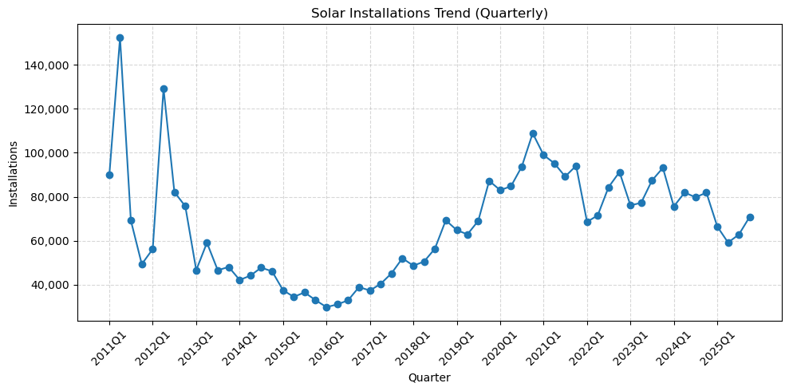

```python
import matplotlib.pyplot as plt
import numpy as np
import matplotlib.ticker as ticker

#calculate the quarterly installtion ove time but exclude 2026Q1 as imcompleted quarter data
df_quarter_ins = (df_merged[df_merged['quarter']!= "2026Q1"].groupby('quarter')['install_qty'].sum().sort_index().reset_index())

#plot the data to line chart

plt.figure(figsize=(10,5))
plt.plot(df_quarter_ins['quarter'].dt.to_timestamp(), df_quarter_ins['install_qty'], marker='o')
plt.title('Solar Installations Trend (Quarterly)')
plt.xlabel('Quarter')
plt.ylabel('Installations')
plt.gca().yaxis.set_major_formatter(
    ticker.StrMethodFormatter('{x:,.0f}')
)

plt.grid(True, linestyle='--', alpha=0.5)
plt.xticks(
    df_quarter_ins['quarter'].dt.to_timestamp()[::4],
    df_quarter_ins['quarter'].astype(str)[::4],
    rotation=45)

plt.tight_layout()
plt.show()
```

**Capacity Growth Trend : Total Capacity Installed Over Time**

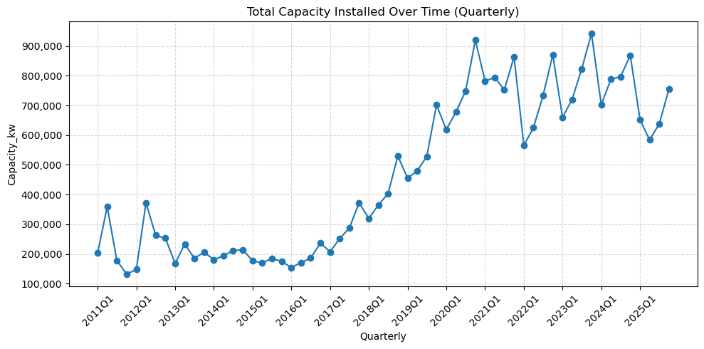

```python
# calculate the Total Capacity Installed Over Time
df_quarter_cap = (df_merged[df_merged['quarter']!= "2026Q1"].groupby('quarter')['capacity_kw'].sum().sort_index().reset_index())

#Plot the data to line chart
plt.figure(figsize=(10,5))
plt.plot(df_quarter_cap['quarter'].dt.to_timestamp(), df_quarter_cap['capacity_kw'], marker='o')
plt.title('Total Capacity Installed Over Time (Quarterly)')
plt.xlabel('Quarterly')
plt.ylabel('Capacity_kw')
plt.gca().yaxis.set_major_formatter(
    ticker.StrMethodFormatter('{x:,.0f}')
)
plt.grid(True, linestyle='--', alpha=0.5)
plt.xticks(
    df_quarter_cap['quarter'].dt.to_timestamp()[::4],
    df_quarter_cap['quarter'].astype(str)[::4],
    rotation=45
)
plt.tight_layout()
plt.show()
```

**Combine installation and capacity trend**

*Note:The data has been normalized for visualization purposes, as installation and capacity are measured on different scales.*

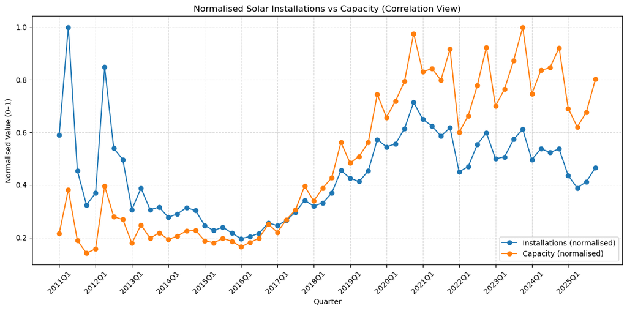

```python
#plot the Installation vs Capacity Collrelation View

ins = df_quarter_ins.copy()
cap = df_quarter_cap.copy()

ins['install_norm'] = ins['install_qty'] / ins['install_qty'].max()
cap['capacity_norm'] = cap['capacity_kw'] / cap['capacity_kw'].max()

plt.figure(figsize=(12,6))

plt.plot(ins['quarter'].astype(str), ins['install_norm'], label='Installations (normalised)', marker='o')
plt.plot(cap['quarter'].astype(str), cap['capacity_norm'], label='Capacity (normalised)', marker='o')

plt.title('Normalised Solar Installations vs Capacity (Correlation View)')
plt.xlabel('Quarter')
plt.ylabel('Normalised Value (0–1)')
plt.xticks(ins['quarter'].astype(str)[::4], rotation=45)
plt.legend()
plt.grid(True, linestyle='--', alpha=0.5)

plt.tight_layout()
plt.show()
```

#### Section 3 — Geographic Insights

**State Comparison Dashboard :Installations by State**

[output not shown]

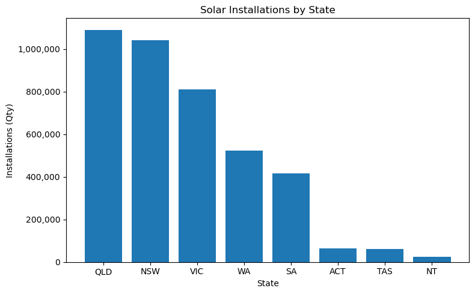

```python
#compare the state installation
df_state = (df_merged.groupby('state')['install_qty'].sum().sort_values(ascending = False).reset_index())

# plot the data to bar chart
plt.figure(figsize=(8,5))
plt.bar(df_state['state'], df_state['install_qty'])
plt.title('Solar Installations by State')
plt.xlabel('State')
plt.ylabel('Installations (Qty)')
plt.gca().yaxis.set_major_formatter(
    ticker.StrMethodFormatter('{x:,.0f}')
)
plt.tight_layout()
plt.show()
```

**Top 10 Solar Postcodes:**

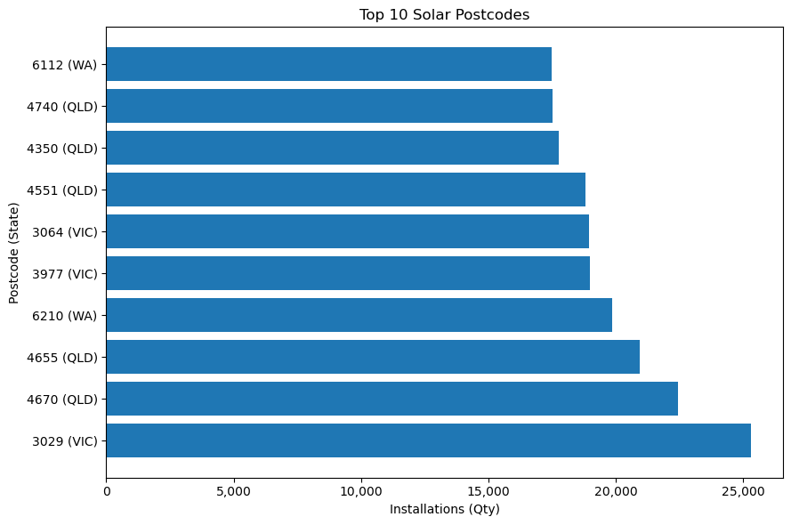

```python
# group top 10 postcode with state
df_top_pc = (
    df_merged.groupby(['postcode', 'state'])['install_qty']
    .sum()
    .sort_values(ascending=False)
    .head(10)
    .reset_index()
)

# create combined label
df_top_pc['postcode_state'] = (
    df_top_pc['postcode'].astype(str) + ' (' + df_top_pc['state'] + ')'
)

# plot
plt.figure(figsize=(9,6))

plt.barh(
    df_top_pc['postcode_state'],
    df_top_pc['install_qty']
)

plt.title('Top 10 Solar Postcodes')
plt.xlabel('Installations (Qty)')
plt.ylabel('Postcode (State)')

plt.gca().xaxis.set_major_formatter(
    ticker.StrMethodFormatter('{x:,.0f}')
)

plt.tight_layout()
plt.show()
```

#### Section 4 — Solar Adoption Rate Per Capita Analysis

- Solar Adoption Rate by State 2011-2025 (per capita)

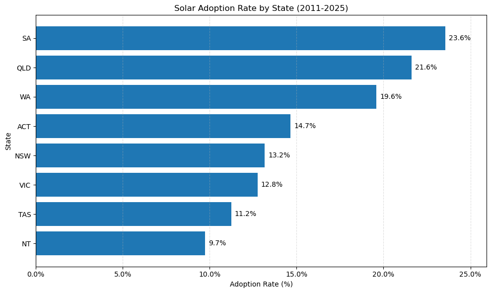

```python
import matplotlib.pyplot as plt
import matplotlib.ticker as ticker

df_install_state = (df_merged.groupby('state')['install_qty'].sum().reset_index())
df_pop_state = (df_merged.groupby('state')['population'].mean().reset_index())

df_per_cap = df_install_state.merge(df_pop_state, on='state')
df_per_cap['install_per_capita'] = (df_per_cap['install_qty'] / df_per_cap['population'])
df_per_cap = df_per_cap.sort_values('install_per_capita', ascending=True)

# Plot
plt.figure(figsize=(10,6))

bars = plt.barh(df_per_cap['state'],df_per_cap['install_per_capita'])

plt.title('Solar Adoption Rate by State (2011-2025)')
plt.xlabel('Adoption Rate (%)')
plt.ylabel('State')

# Format as percentage
plt.gca().xaxis.set_major_formatter(ticker.PercentFormatter(1))

# Add labels
for bar in bars:
    width = bar.get_width()
    plt.text(
        width + 0.002,
        bar.get_y() + bar.get_height()/2,
        f'{width:.1%}',
        va='center'
    )

plt.xlim(0, df_per_cap['install_per_capita'].max()*1.1)

plt.grid(axis='x', linestyle='--', alpha=0.4)

plt.tight_layout()
plt.show()
```

- Solar Adoption Rate by State Insights:

South Australia leads solar adoption rate(installation per capita) at 23.6%, followed by Queensland and Western Australia, while Tasmania and Northern Territory show the lowest uptake, highlighting strong regional differences influenced by sunlight, housing type, and policy incentives.

#### Section 5 — Year-on-Year Growth

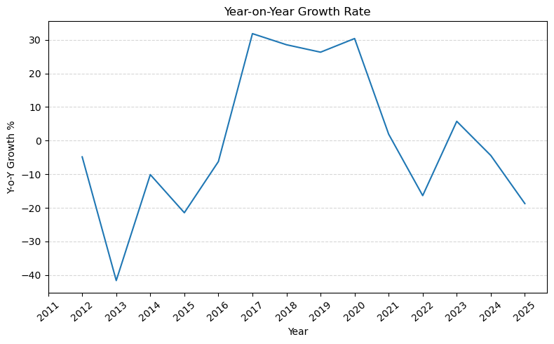

```python
#Year on Year Growth
df_year = (df_merged.groupby('year')['install_qty'].sum().reset_index())
df_year = df_year[df_year['year'] < 2026] # exclude 2026 incompleted quarter data
df_year['growth'] = df_year['install_qty'].pct_change() * 100

# plot the year-on-year trend

plt.figure(figsize=(8,5))
plt.plot(df_year['year'], df_year['growth'])
plt.grid(True, axis = 'y',linestyle='--', alpha=0.5)
plt.title('Year-on-Year Growth Rate')
plt.xlabel('Year')
plt.ylabel('Y-o-Y Growth %')
plt.xticks(df_year['year'],rotation = 40)
plt.tight_layout()
plt.show()
```

## Discussion

The analysis shows clear differences in rooftop solar adoption across Australian states (2011–2025), driven by geography, housing type, and policy support.

South Australia leads significantly with 23.6% adoption, reflecting strong incentives and high energy costs. Queensland (21.6%) and Western Australia (19.6%) also show strong uptake due to favourable sunlight conditions and higher rates of detached housing.

New South Wales (13.2%) and Victoria (12.8%) show moderate adoption despite large populations, likely due to urban density and more apartment living. Tasmania (11.2%) and Northern Territory (9.7%) record the lowest adoption, influenced by environmental and infrastructure limitations.

Overall, solar adoption varies widely across states, with stronger performance in sunnier and less urbanised regions.

## Recommendations

#### 1. Target NSW and VIC for adoption growth

Since NSW and VIC represent large populations but relatively lower adoption rates, we can making them key growth areas. Improve uptake through higher rebates, faster approvals, and support for apartment solar solutions. My recommended Policy interventions such as:

- Increased rebates for rooftop solar
- Streamlined approval processes for installations
- Incentives for apartment solar solutions

Those processes could significantly improve uptake.

#### 2. Maintain and expand incentives in high-performing states (SA, QLD, WA)

South Australia, Queensland, and Western Australia already show strong adoption. However, continued support is important to:

- Sustain momentum
- Encourage battery storage adoption
- Prevent market saturation slowdown

We can focus shift from adoption to energy storage and system optimisation.

#### 3. Develop tailored strategies for low-adoption regions (TAS, NT)

Tasmania and Northern Territory require region-specific strategies, such as:

- Community solar projects (shared solar farms)
- Government-supported installations
- Off-grid or hybrid energy systems in remote areas

These regions may not scale through rooftop solar alone due to environmental and demographic constraints.

#### 4. Promote apartment and urban solar solutions

Lower adoption in NSW and VIC highlights the need for:

- Shared solar schemes (virtual net metering)
- Building-integrated solar systems
- Community energy models

This addresses structural barriers in high-density urban environments.

#### 5. Enhance data-driven monitoring of solar adoption

To improve future decision-making:

1. Track adoption at quarterly/state level consistently
2. Standardise population adjustments (per capita metrics)
3. Incorporate weather, income, and housing data for deeper insights

This will enable more precise policy targeting and forecasting.

## References

- Clean Energy Regulator, Australian Government (2026), Quarterly Carbon Market Report September Quarter 2022, https://cer.gov.au/markets/reports-and-data/quarterly-carbon-market-reports/quarterly-carbon-market-report-september-quarter-2022/small-scale-technology-certificates-stcs
- Department of Climate Change, Energy, the Environment and Water (2024), Solar rebates and incentives, Australian Government, viewed 18 April 2026, https://www.energy.gov.au

## Appendices

Extra data sources:

1. https://github.com/matthewproctor/australianpostcodes/blob/master/australian_postcodes.csv : australian_postcode.csv
2. https://www.abs.gov.au/statistics/people/population/national-state-and-territory-population/latest-release#states-and-territories' : Population - states and territories (Population_by_State 2011_2025.csv)

```
                                                     - End -
```